# Importing T-matrices in TERMS

03 September, 2024

## Objective

This example illustrates how to use TERMS with input T-matrices in `.tmat.h5` format. The structure consists of a dimer of gold spheroids in a chiral configuration. The T-matrix of a spheroid was pre-computed with a separate program: [JCMsuite](https://jcmwave.com/jcmsuite) (a Finite-Element package; this T-matrix is [available in the T-matrix database](https://github.com/tfp-photonics/tmatrix_data_format)), or [SMARTIES](https://www.wgtn.ac.nz/scps/research/research-groups/raman-lab/numerical-tools/smarties) (a T-matrix method).

## SMARTIES T-matrix

The T-matrix file was previously created with [SMARTIES](https://www.wgtn.ac.nz/scps/research/research-groups/raman-lab/numerical-tools/smarties) using these parameters

```bash
cat smarties.m
```

```
path(pathdef); % clear previous path changes
addpath(genpath('~/Documents/nano-optics/smarties/'));
addpath(genpath('~/Documents/nano-optics/easyh5/'));
clearvars;

%% example

% prolate Au spheroid in water
% semi-axes a=b=20nm, c=40nm

% wavelengths and epsilon loaded from file (interpolated JJ data)
load('epsAuJC.mat')
epsAuJC
wavelength = epsAuJC.wavelength(1:1:end)';
Nl = length(wavelength);
epsilon = epsAuJC.epsilon(1:1:end).';

medium=1.33;

% constant simulation parameters
stParams.a=20;
stParams.c=40;

% internal options
stOptions.bGetR = false;
stOptions.Delta = 0;
stOptions.NB = 0; % NB will be estimated automatically
stOptions.bGetSymmetricT = false;
stOptions.bOutput = false; % verbosity


globalN = 3;
globalnNbTheta = 300;

% allocate 3D array for all results
qmax = 2*(globalN*(globalN + 1) + globalN );
tmatrix = zeros(Nl, qmax, qmax);

out = ['smarties.txt'];
fileID = fopen(out, 'w');
format = '%3d %3d %3d %3d %3d %3d %.15e %.15e\n';
fprintf(fileID, '# s sp n np m mp Tr Ti | a= %g c= %g\n', stParams.a, stParams.c);

for i=1:Nl
    stParams.k1=medium*2*pi/wavelength(i);
    stParams.s=sqrt(epsilon(i)) / medium;

    stParams.N=globalN; stParams.nNbTheta=globalnNbTheta;

    [stCoa, stT] = slvForT(stParams,stOptions);

    [T, q, qp] = exportTmatrix( stT, true, [], format);
    % plain text version for comparison
    fprintf(fileID, '# lambda= %g nelements= %d epsIn= %f%+fj\n', ...
        wavelength(i),size(T, 1),real(epsilon(i)), imag(epsilon(i)));
    fprintf(fileID, format, T.');

    % convert these indices to (u,up) for treams convention
    [u] = treams_indexing(q, qmax);
    [up] = treams_indexing(qp, qmax);
    % and find linear indices in 3D array to insert these elements
    ind = sub2ind(size(tmatrix),q*0+i, u, up);
    tmatrix(ind) =  T(:,7) + 1i*T(:,8);

end
fclose(fileID);

analytical_zeros = true(qmax,qmax);
analytical_zeros(sub2ind(size(analytical_zeros), u, up)) = false;


%% data to export

epsilon = struct(...
    'embedding', medium^2,...
    'particle', epsilon, ...
    'embedding_name', 'H2O, Water', ...
    'embedding_keywords', 'non-dispersive',...
    'embedding_reference', 'constant', ...
    'material_name', 'Au, Gold', ...
    'material_reference', 'Au from Raschke et al 10.1103/PhysRevB.86.235147',...
    'material_keywords', 'dispersive, plasmonic');

geometry = struct('radiusxy', stParams.a, 'radiusz', stParams.c);


computation = struct('description', 'Computation using SMARTIES, a numerically robust EBCM implementation for spheroids', ...
    'accuracy', 0.0, ... % not determined in this example
    'Lmax', globalN, ...
    'Ntheta', globalnNbTheta, ...
    'analytical_zeros', analytical_zeros);

comments = struct('name', 'Au prolate spheroid in water',...
    'description', 'Computation using SMARTIES, a numerically robust EBCM implementation for spheroids',...
    'keywords', 'gold, spheroid, ebcm', ...
    'script', [mfilename '.m']);


[f] = tmatrix_hdf5('smarties.tmat.h5', tmatrix, wavelength, epsilon, geometry, computation, comments)
```

The input file for TERMS is

```
ModeAndScheme 2 3
MultipoleCutoff 3 3 -3
Wavelength 400 800 200
Medium 1.7689
OutputFormat HDF5 smarties_dimer
TmatrixFiles 1
smarties.tmat.h5
Scatterers 2
TF1 0 -50 0 40 0 0 0 2
TF1 0  50 0 40 0 0.7853982 0 2
```

Note that only `vacuum_wavelength` in nanometres is supported, and the wavelengths much match exactly. TERMS does not check the embedding medium, so it also the user’s responsibility to ensure they are identical.

and produces an output file `smarties_dimer.h5` storing the simulated results.

## JCMsuite T-matrix

For comparison, we also run the same simulation with a T-matrix obtained via Finite-element simulations using JCMsuite. Below is a plot comparing the results.

This simulation uses the following `input` file

[output not shown]

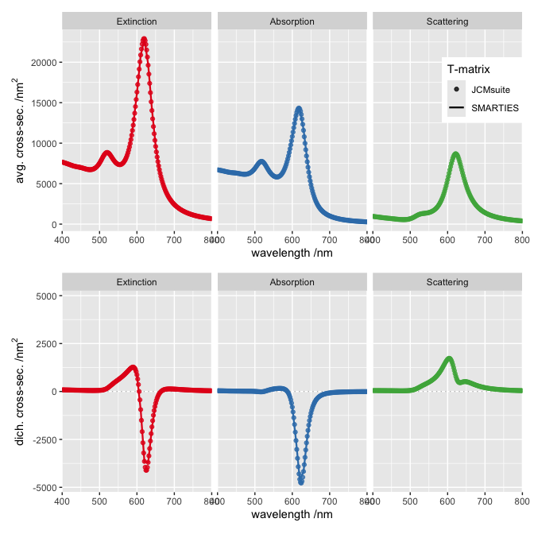

The two simulations show excellent agreement.

*Last run: 03 September, 2024*